# Bayesian Ideal Point Estimation of the Italian Chamber of Deputies

Lodovico Monteforte

2026-05-22

## Introduction

This project estimates the ideological positions of members of the Italian Chamber of Deputies using the Bayesian ideal point model introduced by Clinton, Jackman and Rivers (2004).[^1] The method recovers latent ideological positions — ideal points — from the observed pattern of Yea/Nay votes on roll calls, treating the voting record as data and ideology as an unobserved quantity to be estimated.

The Italian institutional setting offers a particularly rich testing ground. The Chamber has 400 members (compared to 100 in the US Senate), supports a highly fragmented multi-party system, and has experienced substantial governmental instability across legislatures. In practice this means that the relative distance between any two candidates changes as new government coalitions come into being.  
Two legislatures are analysed:

- XIX Legislature (13 October 2022 — present): the current centre-right government led by Giorgia Meloni, with a clear and stable majority coalition. This serves as a baseline case where a strong ideological separation is expected a priori.
- XVIII Legislature (23 March 2018 — 12 October 2022): a more complex case involving three distinct governments (the M5S-Lega coalition, the M5S-PD-IV coalition, and the Draghi technocratic government).

The analysis is carried out using the `pscl` package[^2] by Simon Jackman — one of the original authors of the paper — which implements a Gibbs sampler. The following sections present the theoretical foundations of the model, the data pipeline, and the results for both legislatures.

## Theory

### The Spatial Voting Model

A classical building block of positive political theory is the **spatial voting model**. Each legislator is modelled as a rational utility maximiser with an ideal point in a $d$-dimensional policy space: a point representing their most preferred policy position. The closer a proposed policy is to a legislator’s ideal point, the higher their utility from supporting it.

We assume $n$ legislators vote on $m$ roll calls. For each roll call $j$, legislator $i$ chooses between a Yea position ($\zeta_j$) and a Nay position ($\psi_j$) in the policy space. The utility functions are:

$$U_i(\zeta_j) = -\|x_i - \zeta_j\|^2 +
\eta_{ij}$$
$$U_i(\psi_j) = -\|x_i -
\psi_j\|^2 + \nu_{ij}$$

where $x_i \in \mathbb{R}^d$ is the ideal point of legislator $i$, and $\eta_{ij}$, $\nu_{ij}$ are stochastic error terms capturing unobserved utility. A legislator votes Yea ($y_{ij} = 1$) if:

$$P(y_{ij} = 1) = P(U_i(\zeta_j) >
U_i(\psi_j))$$

Expanding the Euclidean distance terms ($\|a - b\|^2 = a'a - 2a'b + b'b$):

$$\|x_i - \psi_j\|^2 - \|x_i - \zeta_j\|^2
= 2(\zeta_j - \psi_j)'x_i +
\psi_j'\psi_j - \zeta_j'\zeta_j$$

Assuming the error difference $\epsilon_{ij} = \nu_{ij} - \eta_{ij}$ is distributed $N(0, \sigma_j^2)$ and normalising by $\sigma_j$:

$$P(y_{ij} = 1) = \Phi \left(
\frac{2(\zeta_j - \psi_j)'}{\sigma_j}x_i -
\frac{\zeta_j'\zeta_j - \psi_j'\psi_j}{\sigma_j}
\right)$$

We now define:

- $\beta_j = \frac{2(\zeta_j - \psi_j)}{\sigma_j}$: as the discrimination parameter, capturing how strongly vote $j$ separates legislators along the ideological dimension. A large $|\beta_j|$ indicates a highly partisan vote; a near-zero $\beta_j$ indicates a vote on which ideology plays little role.
- $\alpha_j = \frac{\zeta_j'\zeta_j - \psi_j'\psi_j}{\sigma_j}$: the difficulty parameter, capturing the overall propensity to vote Yea regardless of ideology.

The probability of a Yea vote becomes a standard probit model:

$$P(y_{ij} = 1) = \Phi(x_i'\beta_j -
\alpha_j)$$

With the joint likelihood for the observed vote matrix $Y$, assuming independence across legislators and roll calls, is:

$$L(\mathbf{B}, \alpha, \mathbf{X} \mid Y)
= \prod_{i=1}^{n} \prod_{j=1}^{m}
\Phi(x_i'\beta_j - \alpha_j)^{y_{ij}}
\left[1 - \Phi(x_i'\beta_j - \alpha_j)\right]^{1 -
y_{ij}}$$

where $\mathbf{X}$ is the $n \times d$ matrix of ideal points and $\mathbf{B}$ is the $m \times d$ matrix of discrimination parameters.

Clinton et al. (2004) notice that the posterior $p(\mathbf{X}, \mathbf{B}, \alpha \mid Y)$ has a tractable conditional structure under conjugate priors, enabling estimation via Gibbs sampling.

The Gibbs sampler iteratively draws from the conditional posteriors:

1. For $t = 1$ to $T$:
2. Sample $x_i^{(t+1)}$ from $p(x_i \mid \mathbf{B}^{(t)}, \alpha^{(t)}, Y)$ for all $i$
3. Sample $(\beta_j^{(t+1)}, \alpha_j^{(t+1)})$ from $p(\beta_j, \alpha_j \mid \mathbf{X}^{(t+1)}, Y)$ for all $j$
4. Update $\theta^{(t+1)} \leftarrow (x^{(t+1)}, \beta^{(t+1)}, \alpha^{(t+1)})$

What makes it tractable here is the Albert-Chib data augmentation: by introducing latent continuous variables $z_{ij}$ such that $y_{ij} = \mathbf{1}[z_{ij} > 0]$ with $z_{ij} \sim N(x_i'\beta_j - \alpha_j, 1)$, the conditional posteriors for both ideal points and bill parameters become Gaussian, enabling closed-form sampling at each step.

### Identification

The model has two sources of non-identification:

1. **Sign flip**: multiplying all $x_i$ by $-1$ and all $\beta_j$ by $-1$ leaves the likelihood unchanged.
2. **Scale**: multiplying all ideal points by a constant $c$ and dividing all $\beta_j$ by $c$ leaves the likelihood unchanged.

Both are resolved by fixing the ideal points of two legislators to known values. We use **Fratoianni Nicola** (left, fixed at $-1$) and **Lollobrigida Francesco** (right, fixed at $+1$) as anchors. Both are long-serving members of their respective parties with stable and well-known ideological positions, making them suitable anchor choices. —

## Data

### Source and Scraping Pipeline

Vote data was obtained from the Italian Chamber of Deputies open data portal (`dati.camera.it`). For each legislature, we queried all final votes (`votazioneFinale = 1`), excluding procedural votes. For each vote, we retrieved the legislator’s name, vote expression (Yea/Nay/Abstain), and party group affiliation at the date of the vote — the latter using date filters to correctly assign party membership for legislators who switched groups mid-legislature.

The scraping pipeline is implemented in Python and supports automatic resume on interruption. The full scrape takes approximately 20 minutes per legislature.

### Preprocessing

The raw dataset (one row per legislator per vote) was transformed into a legislator × vote binary matrix where 1 = Yea, 0 = Nay, and NA = absent or abstaining. Party names were standardised from the verbose raw labels to short identifiers (e.g. `"FRATELLI D'ITALIA (FDI) (18.10.2022"` → `"FdI"`).

Legislators who switched party mid-legislature were collapsed onto a single identifier, retaining their full voting record but assigned to their last party of affiliation. In theory this could create outliers for extreme party-switchers, but such cases should be rare and do not affect model mechanics since ideal points are estimated from votes, not party labels.

### Sample Reduction

Before estimation, the `pscl::ideal` function applies a lop filter (`lop = 0.05`): roll calls where fewer than 5% of legislators voted on the minority side are dropped as uninformative. The table below reports the approximate effect of this filter on both datasets.

```r
red_18 <- read.csv("sample_reduction_18.csv")
red_19 <- read.csv("sample_reduction_19.csv")
reduction_df <- rbind(red_19, red_18)

knitr::kable(reduction_df,
             col.names = c("Legislature", "Legislators (raw)",
                           "Legislators (no votes)",
                           "Votes (raw)", "Votes dropped (lop < 0.05)",
                           "Votes kept"),
             caption = paste("Sample reduction after lop = 0.05 filter.",
                             "Note: counts are approximate — exact filtering",
                             "is performed by ideal() in R."))
```

Sample reduction after lop = 0.05 filter. Note: counts are approximate — exact filtering is performed by ideal() in R.

| Legislature | Legislators (raw) | Legislators (no votes) | Votes (raw) | Votes dropped (lop < 0.05) | Votes kept |
| --- | --- | --- | --- | --- | --- |
| XIX | 413 | 0 | 364 | 190 | 174 |
| XVIII | 659 | 0 | 303 | 201 | 102 |

## Results: XIX Legislature (2022–present)

```r
load("session_19.RData")
load("sensitivity_19.RData")

all_parties <- sort(unique(c(
  "FdI", "FI", "IPF-IC", "M5S", "MISTO", "IV", "Lega", "PD", "LEU-ART1-SI",
  "PD-IDP", "AZ-PER-RE", "AVS", "IV-C-RE", "NM"
)))

master_colors <- setNames(
  scales::viridis_pal(option = "turbo")(length(all_parties)),
  all_parties
)
```

### Ideological Distribution

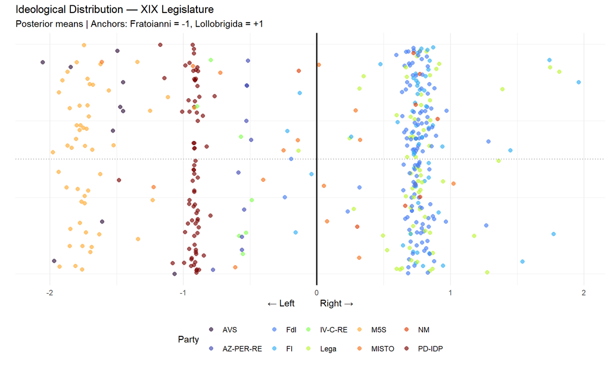

Posterior mean ideal points for all XIX legislature members. Vertical jitter is purely cosmetic to avoid overplotting. The vertical line marks the ideological centre (0).

```r
plot_df_19 <- data.frame(
  legis.name = rownames(id_19$xbar),
  Estimate   = as.numeric(id_19$xbar[, 1]),
  stringsAsFactors = FALSE
)
plot_df_19 <- merge(plot_df_19, data19[, c("legis.name", "partito")],
                    by = "legis.name", all.x = TRUE)

set.seed(42)
ggplot(plot_df_19, aes(x = Estimate, y = 0, color = partito)) +
  geom_jitter(size = 2, alpha = 0.65, height = 0.15) +
  geom_hline(yintercept = 0, linetype = "dotted", color = "gray50") +
  geom_vline(xintercept = 0, linewidth = 0.8, color = "black") +
  scale_color_manual(values = master_colors) +
  theme_minimal() +
  labs(title    = "Ideological Distribution — XIX Legislature",
       subtitle = "Posterior means | Anchors: Fratoianni = -1, Lollobrigida = +1",
       x        = "← Left          Right →",
       y        = "", color = "Party") +
  theme(axis.text.y = element_blank(), axis.ticks.y = element_blank(),
        panel.grid.major.y = element_blank(), legend.position = "bottom")
```

The model recovers a clean left-right separation consistent with the known political landscape of the XIX legislature. The right-wing governing coalition (FdI, Lega, FI, NM) clusters compactly on the right, while the opposition (PD-IDP, AVS, M5S) occupies the left. AVS is correctly placed further left than PD-IDP. The M5S occupies a hard-left position.

### Bill Parameters

Another parameter of interest is the discrimination parameter $\beta_j$. This measures how strongly each vote separates left from right legislators. Its distribution tells us how well voting patterns map onto a single ideological axis, and whether a single ideological dimension is sufficient to explain voting behaviour. A concentration of near-zero $\beta_j$ values would indicate that many votes carry little ideological signal; systematic departures from a unimodal legislator distribution would instead suggest the need for an additional dimension beyond left and right.

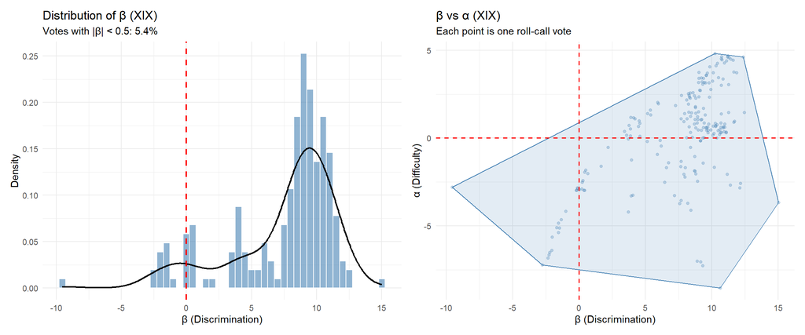

Left: distribution of bill discrimination parameters. Right: discrimination vs difficulty for all votes.

```r
beta_df_19 <- data.frame(
  vote_id = 1:nrow(id_19$betabar),
  beta    = id_19$betabar[, 1],
  alpha   = id_19$betabar[, 2]
)
noisy_pct_19 <- round(mean(abs(beta_df_19$beta) < 0.5) * 100, 1)

p_hist <- ggplot(beta_df_19, aes(x = beta)) +
  geom_histogram(aes(y = after_stat(density)),
                 bins = 50, fill = "steelblue", color = "white", alpha = 0.6) +
  geom_density(color = "black", linewidth = 0.8, adjust = 1.5) +
  geom_vline(xintercept = 0, linetype = "dashed", color = "red", linewidth = 0.8) +
  theme_minimal() +
  labs(title    = "Distribution of β (XIX)",
       subtitle = paste0("Votes with |β| < 0.5: ", noisy_pct_19, "%"),
       x = "β (Discrimination)", y = "Density")

hull_idx_19 <- chull(beta_df_19$beta, beta_df_19$alpha)
hull_df_19  <- beta_df_19[hull_idx_19, ]

p_scatter <- ggplot(beta_df_19, aes(x = beta, y = alpha)) +
  geom_polygon(data = hull_df_19, fill = "steelblue", alpha = 0.15,
               color = "steelblue", linewidth = 0.5) +
  geom_point(alpha = 0.3, size = 1.2, color = "steelblue") +
  geom_vline(xintercept = 0, linetype = "dashed", color = "red", linewidth = 0.6) +
  geom_hline(yintercept = 0, linetype = "dashed", color = "red", linewidth = 0.6) +
  theme_minimal() +
  labs(title    = "β vs α (XIX)",
       subtitle = "Each point is one roll-call vote",
       x = "β (Discrimination)", y = "α (Difficulty)")

p_hist + p_scatter
```

### A side note on convergence and party mechanics

The model was run for 150,000 iterations. Assessing convergence via the Geweke diagnostic — which tests whether the mean of the first 10% of the chain equals the mean of the last 50% — reveals that a large share of individual ideal point parameters do not converge (see table below). This is a known limitation of the model: we have to assume non strategic, truthful voting. In a setting like the Italian parliament operates under strong party whipping, producing low heterogeneity in voting behaviour within parties and making precise estimation of *individual* ideal points difficult regardless of chain length. Nevertheless, the estimates remain informative about the relative positioning of parties along the left-right spectrum. Since legislators within the same party vote near-identically, what the model recovers is a reliable signal of *inter-party* ideological distances, which is the quantity of primary interest in our analysis.

```r
leg_19   <- as.mcmc(id_19$x[, , 1])
beta_19  <- as.mcmc(id_19$beta[, , 1])
alpha_19 <- as.mcmc(id_19$beta[, , 2])

gw_leg_19   <- geweke.diag(leg_19)
gw_beta_19  <- geweke.diag(beta_19)
gw_alpha_19 <- geweke.diag(alpha_19)

geweke_df_19 <- data.frame(
  Parameter  = c("Ideal Points", "β (Discrimination)", "α (Difficulty)"),
  Total      = c(id_19$n, id_19$m, id_19$m),
  Failed     = c(sum(abs(gw_leg_19$z)   > 1.96),
                 sum(abs(gw_beta_19$z)  > 1.96),
                 sum(abs(gw_alpha_19$z) > 1.96)),
  Pass_Rate  = paste0(round((1 - c(
                 mean(abs(gw_leg_19$z)   > 1.96),
                 mean(abs(gw_beta_19$z)  > 1.96),
                 mean(abs(gw_alpha_19$z) > 1.96))) * 100, 1), "%")
)

knitr::kable(geweke_df_19,
             col.names = c("Parameter", "Total", "Failed (|Z| > 1.96)",
                           "Pass Rate"),
             caption = "Geweke Convergence Diagnostics — XIX Legislature (1D)")
```

Geweke Convergence Diagnostics — XIX Legislature (1D)

| Parameter | Total | Failed (\|Z\| > 1.96) | Pass Rate |
| --- | --- | --- | --- |
| Ideal Points | 413 | 114 | 72.4% |
| β (Discrimination) | 205 | 40 | 80.5% |
| α (Difficulty) | 205 | 99 | 51.7% |

An important caveat applies to legislators with very few recorded votes. A striking case is Prime Minister Giorgia Meloni, who cast no votes in this legislature — a common pattern among Prime Ministers. With no data, the posterior is entirely determined by the prior $\mathcal{N}(0, 1)$, and the chain will appear to converge trivially since it never moves away from the prior. Her Geweke Z-score is 0.451, which is below the 1.96 threshold — a formally convergent but entirely uninformative result.

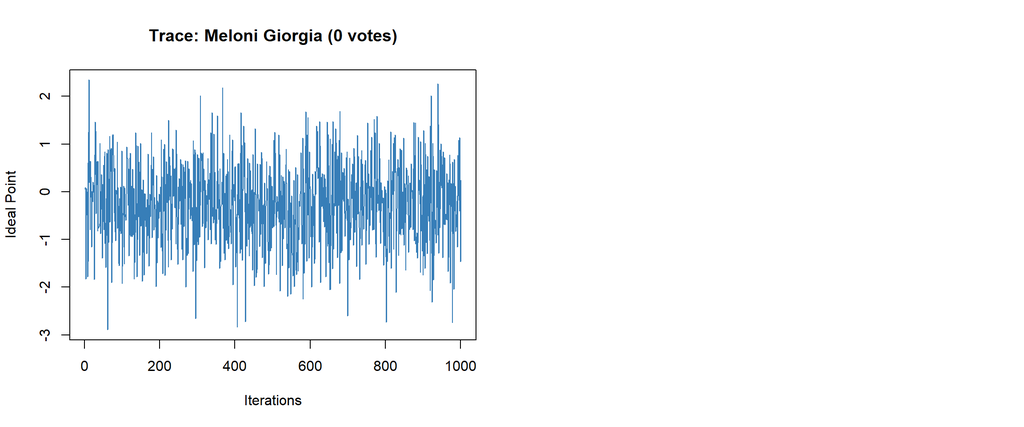

Trace plots for Meloni (no data, prior-dominated).

```r
idx_meloni   <- grep("MELONI GIORGIA",   colnames(leg_19))

par(mfrow = c(1, 2))
coda::traceplot(leg_19[, idx_meloni],
                main = "Trace: Meloni Giorgia (0 votes)",
                col = "#377EB8", ylab = "Ideal Point")
```

### Sensitivity to Bill Prior Specification

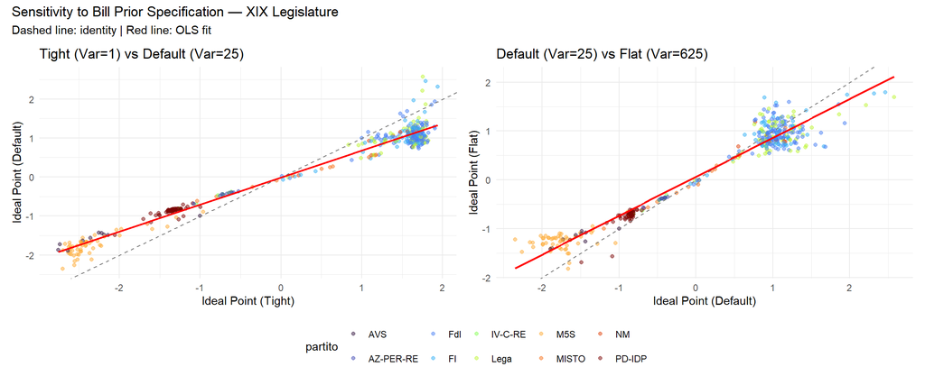

Each point is one legislator. Points on the dashed identity line are unaffected by prior choice.

```r
ideal_comp_19 <- data.frame(
  legis.name = rownames(id_1_19$xbar),
  Tight      = as.numeric(id_1_19$xbar[, 1]),
  Default    = as.numeric(id_2_19$xbar[, 1]),
  Flat       = as.numeric(id_3_19$xbar[, 1]),
  stringsAsFactors = FALSE
)
ideal_comp_19 <- merge(ideal_comp_19, data19[, c("legis.name", "partito")],
                       by = "legis.name", all.x = TRUE)

p_c1_19 <- ggplot(ideal_comp_19, aes(x = Tight, y = Default, color = partito)) +
  geom_point(alpha = 0.5, size = 1.5) +
  geom_abline(slope = 1, intercept = 0, linetype = "dashed", color = "gray50") +
  geom_smooth(method = "lm", se = FALSE, color = "red",
              linewidth = 0.8, aes(group = 1)) +
  scale_color_manual(values = master_colors, guide = "none") +
  theme_minimal() +
  labs(title = "Tight (Var=1) vs Default (Var=25)",
       x = "Ideal Point (Tight)", y = "Ideal Point (Default)")

p_c2_19 <- ggplot(ideal_comp_19, aes(x = Default, y = Flat, color = partito)) +
  geom_point(alpha = 0.5, size = 1.5) +
  geom_abline(slope = 1, intercept = 0, linetype = "dashed", color = "gray50") +
  geom_smooth(method = "lm", se = FALSE, color = "red",
              linewidth = 0.8, aes(group = 1)) +
  scale_color_manual(values = master_colors) +
  theme_minimal() +
  labs(title = "Default (Var=25) vs Flat (Var=625)",
       x = "Ideal Point (Default)", y = "Ideal Point (Flat)")

p_c1_19 + p_c2_19 +
  plot_layout(guides = "collect") &
  theme(legend.position = "bottom") &
  plot_annotation(
    title    = "Sensitivity to Bill Prior Specification — XIX Legislature",
    subtitle = "Dashed line: identity | Red line: OLS fit")
```

### Data, Uncertainty and Precision

Another point of interest is convergence under low participation. To examine how well the model characterises legislators with few recorded votes, we identify the three least active members for each party and plot their 95% credible intervals.

Legislators with few votes have posteriors dominated by the prior, yielding wide and potentially uninformative estimates. What we observe below, however, is a clear separation of the main parliamentary blocs even in this low-information setting. Coherently with the current political environment, the model distinguishes a solid and cohesive right-wing bloc from a more heterogeneous left, reflecting the asymmetry in party discipline discussed above. Two members of the right-wing bloc do display very wide credible intervals positioned on the left side of the scale, suggesting their posteriors are almost entirely prior-dominated a consequence of near-complete absence from the chamber.

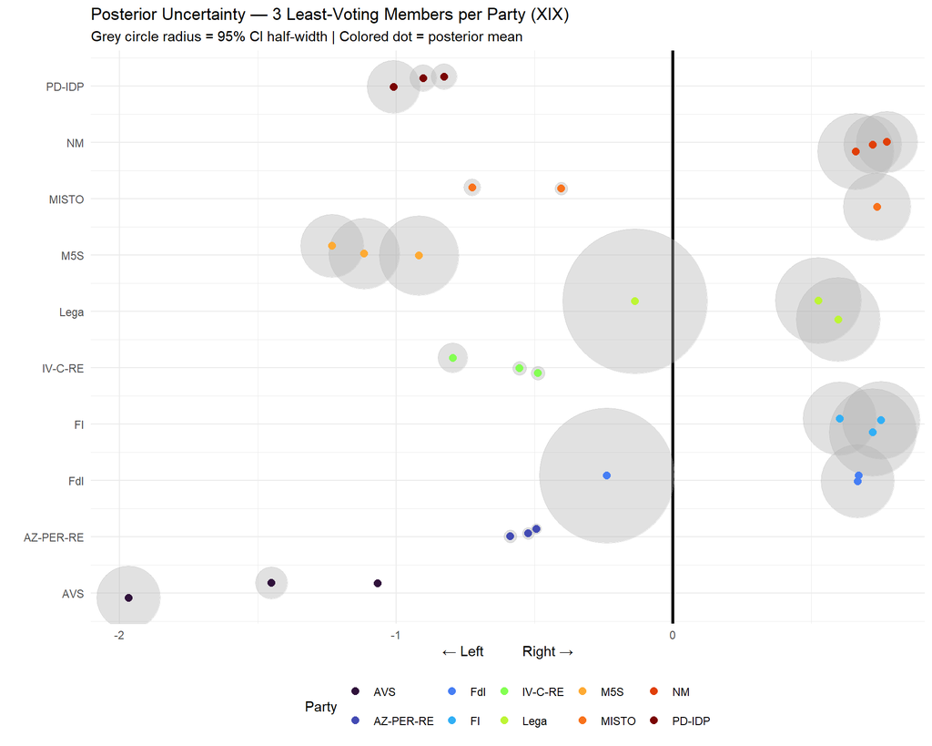

Grey circle size = 95% CI half-width. Colored dot = posterior mean. The vertical line marks the ideological centre.

```r
ci_df_19 <- data.frame(
  legis.name = rownames(id_19$xbar),
  mean       = as.numeric(id_19$xbar[, 1]),
  lower      = apply(id_19$x[, , 1], 2, quantile, 0.025),
  upper      = apply(id_19$x[, , 1], 2, quantile, 0.975),
  stringsAsFactors = FALSE
)
ci_df_19$ci_width <- ci_df_19$upper - ci_df_19$lower

votes_per_leg_19 <- rowSums(!is.na(rc_19$votes))
votes_df_19 <- data.frame(
  legis.name = names(votes_per_leg_19),
  n_votes    = as.numeric(votes_per_leg_19),
  stringsAsFactors = FALSE
)
ci_df_19 <- merge(ci_df_19, data19[, c("legis.name", "partito")],
                  by = "legis.name", all.x = TRUE)
ci_df_19 <- merge(ci_df_19, votes_df_19, by = "legis.name", all.x = TRUE)

low_voters_19 <- ci_df_19 %>%
  group_by(partito) %>%
  slice_min(order_by = n_votes, n = 3, with_ties = FALSE) %>%
  ungroup()

set.seed(42)
low_voters_19$y_jitter <- as.numeric(as.factor(low_voters_19$partito)) +
  runif(nrow(low_voters_19), -0.2, 0.2)

ci_scale <- 15

ggplot(low_voters_19) +
  geom_vline(xintercept = 0, linewidth = 1.2, color = "black") +
  geom_point(aes(x = mean, y = y_jitter, size = ci_width * ci_scale),
             color = "grey70", alpha = 0.4) +
  geom_point(aes(x = mean, y = y_jitter, color = partito), size = 2.5) +
  scale_color_manual(values = master_colors) +
  scale_size_identity() +
  scale_y_continuous(
    breaks = seq_along(levels(as.factor(low_voters_19$partito))),
    labels = levels(as.factor(low_voters_19$partito))) +
  theme_minimal() +
  labs(title    = "Posterior Uncertainty — 3 Least-Voting Members per Party (XIX)",
       subtitle = "Grey circle radius = 95% CI half-width | Colored dot = posterior mean",
       x = "← Left          Right →", y = "", color = "Party") +
  guides(size = "none") +
  theme(legend.position = "bottom")
```

To further discuss the relationship between the richness of data and confidence intervals below we picture the 95% CI width against the number of votes cast. The relationship is consistent with expectations: legislators with very few recorded votes display substantially wider credible intervals, as their posteriors remain prior-dominated. Beyond a moderate participation threshold, however, additional votes contribute diminishing returns to precision — CI width stabilises and the relationship flattens. The slight upward curvature can be imputed to loess edge effects.

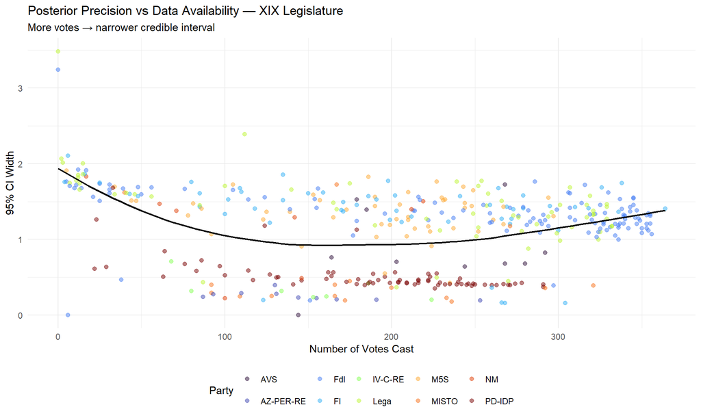

Each point is one legislator. The black LOESS curve shows the average relationship between vote count and posterior precision across the full chamber.

```r
ci_all_19 <- data.frame(
  legis.name = rownames(id_19$xbar),
  mean       = as.numeric(id_19$xbar[, 1]),
  lower      = apply(id_19$x[, , 1], 2, quantile, 0.025),
  upper      = apply(id_19$x[, , 1], 2, quantile, 0.975),
  stringsAsFactors = FALSE
)
ci_all_19$ci_width <- ci_all_19$upper - ci_all_19$lower
ci_all_19 <- merge(ci_all_19, votes_df_19, by = "legis.name", all.x = TRUE)
ci_all_19 <- merge(ci_all_19, data19[, c("legis.name", "partito")],
                   by = "legis.name", all.x = TRUE)

ggplot(ci_all_19, aes(x = n_votes, y = ci_width)) +
  geom_point(aes(color = partito), alpha = 0.5, size = 1.8) +
  geom_smooth(method = "loess", se = FALSE,
              color = "black", linewidth = 0.8) +
  scale_color_manual(values = master_colors) +
  theme_minimal() +
  labs(title    = "Posterior Precision vs Data Availability — XIX Legislature",
       subtitle = "More votes → narrower credible interval",
       x = "Number of Votes Cast", y = "95% CI Width", color = "Party") +
  theme(legend.position = "bottom")
```

## Results: XVIII Legislature (2018–2022)

The XVIII legislature presents a considerably noisier picture. Three distinct governments formed over its course: the M5S-Lega coalition (June 2018 – September 2019), the M5S-PD-IV coalition under Conte II (September 2019 – February 2021), and the broad technocratic government under Mario Draghi (February 2021 – October 2022). This instability means that the left-right signal in the vote record is substantially noisier than in the XIX legislature, as the same party (most notably M5S) voted with very different coalitions at different points in time.

```r
load("session_18.RData")
load("sensitivity_18.RData")

parties_18 <- sort(unique(data18$partito))
party_colors_18 <- setNames(
  scales::viridis_pal(option = "turbo")(length(parties_18)),
  parties_18
)
```

### Ideological Distribution

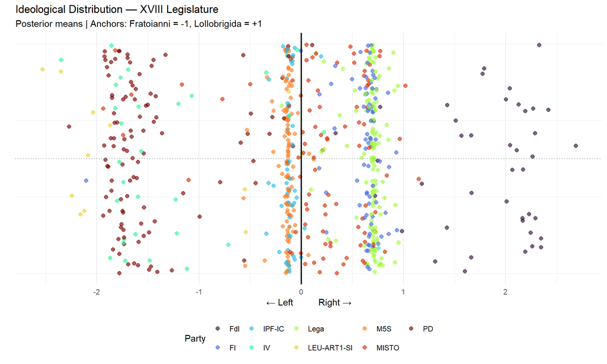

Posterior mean ideal points for all XVIII legislature members.

```r
plot_df_18 <- data.frame(
  legis.name = rownames(id_18$xbar),
  Estimate   = as.numeric(id_18$xbar[, 1]),
  stringsAsFactors = FALSE
)
plot_df_18 <- merge(plot_df_18, data18[, c("legis.name", "partito")],
                    by = "legis.name", all.x = TRUE)

set.seed(42)
ggplot(plot_df_18, aes(x = Estimate, y = 0, color = partito)) +
  geom_jitter(size = 2, alpha = 0.65, height = 0.15) +
  geom_hline(yintercept = 0, linetype = "dotted", color = "gray50") +
  geom_vline(xintercept = 0, linewidth = 0.8, color = "black") +
  scale_color_manual(values = party_colors_18) +
  theme_minimal() +
  labs(title    = "Ideological Distribution — XVIII Legislature",
       subtitle = "Posterior means | Anchors: Fratoianni = -1, Lollobrigida = +1",
       x = "← Left          Right →", y = "", color = "Party") +
  theme(axis.text.y = element_blank(), axis.ticks.y = element_blank(),
        panel.grid.major.y = element_blank(), legend.position = "bottom")
```

### Bill Parameters

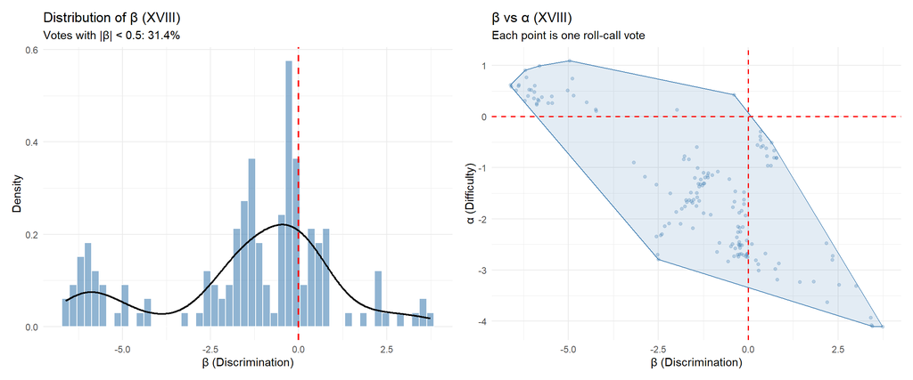

```r
beta_df_18 <- data.frame(
  vote_id = 1:nrow(id_18$betabar),
  beta    = id_18$betabar[, 1],
  alpha   = id_18$betabar[, 2]
)
noisy_pct_18 <- round(mean(abs(beta_df_18$beta) < 0.5) * 100, 1)

p_hist_18 <- ggplot(beta_df_18, aes(x = beta)) +
  geom_histogram(aes(y = after_stat(density)),
                 bins = 50, fill = "steelblue", color = "white", alpha = 0.6) +
  geom_density(color = "black", linewidth = 0.8, adjust = 1.5) +
  geom_vline(xintercept = 0, linetype = "dashed", color = "red", linewidth = 0.8) +
  theme_minimal() +
  labs(title    = "Distribution of β (XVIII)",
       subtitle = paste0("Votes with |β| < 0.5: ", noisy_pct_18, "%"),
       x = "β (Discrimination)", y = "Density")

hull_idx_18 <- chull(beta_df_18$beta, beta_df_18$alpha)
hull_df_18  <- beta_df_18[hull_idx_18, ]

p_scatter_18 <- ggplot(beta_df_18, aes(x = beta, y = alpha)) +
  geom_polygon(data = hull_df_18, fill = "steelblue", alpha = 0.15,
               color = "steelblue", linewidth = 0.5) +
  geom_point(alpha = 0.3, size = 1.2, color = "steelblue") +
  geom_vline(xintercept = 0, linetype = "dashed", color = "red", linewidth = 0.6) +
  geom_hline(yintercept = 0, linetype = "dashed", color = "red", linewidth = 0.6) +
  theme_minimal() +
  labs(title    = "β vs α (XVIII)",
       subtitle = "Each point is one roll-call vote",
       x = "β (Discrimination)", y = "α (Difficulty)")

p_hist_18 + p_scatter_18
```

This legislature shows a substantially higher share of uninformative votes, with 31.4% of bills having $|\beta| < 0.5$. The high share of near-zero discrimination parameters in this legislature may suggest the need for an additional ideological dimension beyond left-right — possibly reflecting the cross-cutting coalition dynamics that characterised the period.

The shift of the M5S from a centrist to a left-leaning position across the two legislatures can be attributed not only to a genuine ideological realignment, but also to a statistical artefact of their governing alliance with the Lega: during that period, M5S voted in favour of bills anchored further to the center-right, which pulls their estimated ideal point toward the center in the XVIII legislature and exaggerates the apparent leftward shift when comparing across legislatures.

### Convergence Diagnostics

```r
leg_18   <- as.mcmc(id_18$x[, , 1])
beta_18  <- as.mcmc(id_18$beta[, , 1])
alpha_18 <- as.mcmc(id_18$beta[, , 2])

gw_leg_18   <- geweke.diag(leg_18)
gw_beta_18  <- geweke.diag(beta_18)
gw_alpha_18 <- geweke.diag(alpha_18)

geweke_df_18 <- data.frame(
  Parameter = c("Ideal Points", "β (Discrimination)", "α (Difficulty)"),
  Total     = c(id_18$n, id_18$m, id_18$m),
  Failed    = c(sum(abs(gw_leg_18$z)   > 1.96),
                sum(abs(gw_beta_18$z)  > 1.96),
                sum(abs(gw_alpha_18$z) > 1.96)),
  Pass_Rate = paste0(round((1 - c(
                mean(abs(gw_leg_18$z)   > 1.96),
                mean(abs(gw_beta_18$z)  > 1.96),
                mean(abs(gw_alpha_18$z) > 1.96))) * 100, 1), "%")
)

knitr::kable(geweke_df_18,
             col.names = c("Parameter", "Total", "Failed (|Z| > 1.96)",
                           "Pass Rate"),
             caption = "Geweke Convergence Diagnostics — XVIII Legislature (1D)")
```

Geweke Convergence Diagnostics — XVIII Legislature (1D)

| Parameter | Total | Failed (\|Z\| > 1.96) | Pass Rate |
| --- | --- | --- | --- |
| Ideal Points | 659 | 33 | 95% |
| β (Discrimination) | 156 | 11 | 92.9% |
| α (Difficulty) | 156 | 10 | 93.6% |

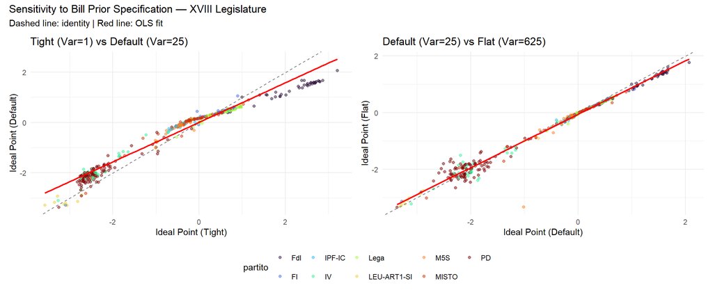

```r
ideal_comp_18 <- data.frame(
  legis.name = rownames(id_1_18$xbar),
  Tight      = as.numeric(id_1_18$xbar[, 1]),
  Default    = as.numeric(id_2_18$xbar[, 1]),
  Flat       = as.numeric(id_3_18$xbar[, 1]),
  stringsAsFactors = FALSE
)
ideal_comp_18 <- merge(ideal_comp_18, data18[, c("legis.name", "partito")],
                       by = "legis.name", all.x = TRUE)

p_c1_18 <- ggplot(ideal_comp_18, aes(x = Tight, y = Default, color = partito)) +
  geom_point(alpha = 0.5, size = 1.5) +
  geom_abline(slope = 1, intercept = 0, linetype = "dashed", color = "gray50") +
  geom_smooth(method = "lm", se = FALSE, color = "red",
              linewidth = 0.8, aes(group = 1)) +
  scale_color_manual(values = party_colors_18, guide = "none") +
  theme_minimal() +
  labs(title = "Tight (Var=1) vs Default (Var=25)",
       x = "Ideal Point (Tight)", y = "Ideal Point (Default)")

p_c2_18 <- ggplot(ideal_comp_18, aes(x = Default, y = Flat, color = partito)) +
  geom_point(alpha = 0.5, size = 1.5) +
  geom_abline(slope = 1, intercept = 0, linetype = "dashed", color = "gray50") +
  geom_smooth(method = "lm", se = FALSE, color = "red",
              linewidth = 0.8, aes(group = 1)) +
  scale_color_manual(values = party_colors_18) +
  theme_minimal() +
  labs(title = "Default (Var=25) vs Flat (Var=625)",
       x = "Ideal Point (Default)", y = "Ideal Point (Flat)")

p_c1_18 + p_c2_18 +
  plot_layout(guides = "collect") &
  theme(legend.position = "bottom") &
  plot_annotation(
    title    = "Sensitivity to Bill Prior Specification — XVIII Legislature",
    subtitle = "Dashed line: identity | Red line: OLS fit")
```

### Data, Uncertainty and Precision

As expected, legislators with few recorded votes have their posteriors dominated by the prior, with ideal point estimates clustered near the center of the scale and very wide, overlapping credible intervals. For most of these MPs the model cannot meaningfully distinguish between individuals — a reminder that the estimates are informative at the party level, but should be interpreted cautiously at the individual level for low-participation legislators.

The overall trend shown below is consistent with expectations: there is a clear negative relationship between the number of votes cast and the width of the credible interval, which flattens at around 100 votes — suggesting that beyond this threshold, additional votes contribute little further precision to the estimates.

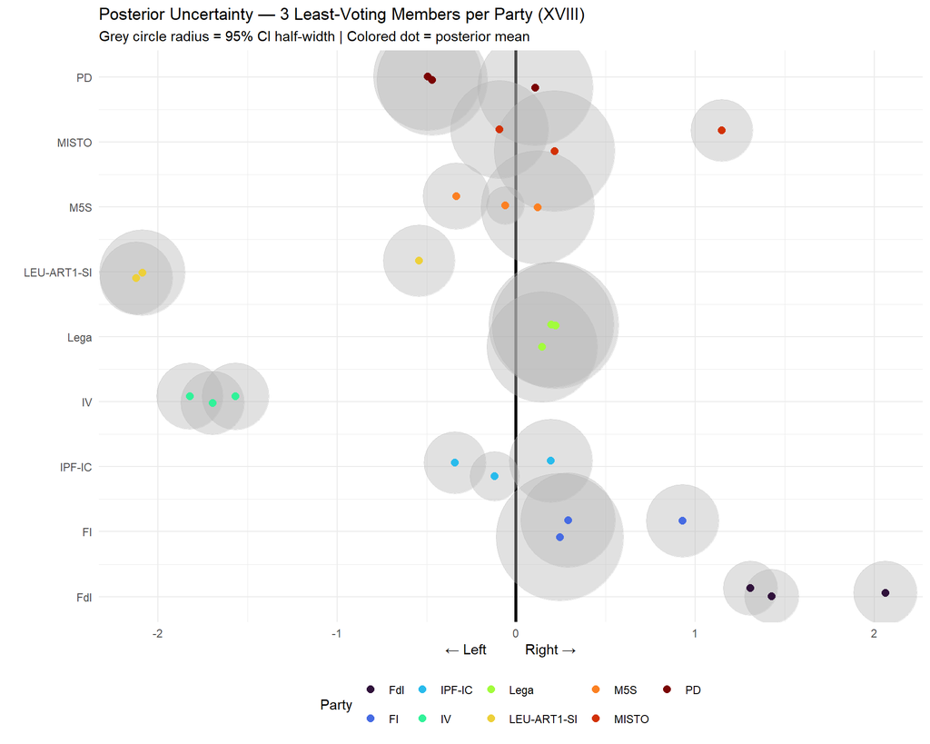

```r
ci_df_18 <- data.frame(
  legis.name = rownames(id_18$xbar),
  mean       = as.numeric(id_18$xbar[, 1]),
  lower      = apply(id_18$x[, , 1], 2, quantile, 0.025),
  upper      = apply(id_18$x[, , 1], 2, quantile, 0.975),
  stringsAsFactors = FALSE
)
ci_df_18$ci_width <- ci_df_18$upper - ci_df_18$lower

votes_per_leg_18 <- rowSums(!is.na(rc_18$votes))
votes_df_18 <- data.frame(
  legis.name = names(votes_per_leg_18),
  n_votes    = as.numeric(votes_per_leg_18),
  stringsAsFactors = FALSE
)
ci_df_18 <- merge(ci_df_18, data18[, c("legis.name", "partito")],
                  by = "legis.name", all.x = TRUE)
ci_df_18 <- merge(ci_df_18, votes_df_18, by = "legis.name", all.x = TRUE)

low_voters_18 <- ci_df_18 %>%
  group_by(partito) %>%
  slice_min(order_by = n_votes, n = 3, with_ties = FALSE) %>%
  ungroup()

set.seed(42)
low_voters_18$y_jitter <- as.numeric(as.factor(low_voters_18$partito)) +
  runif(nrow(low_voters_18), -0.2, 0.2)

ci_scale <- 15

ggplot(low_voters_18) +
  geom_vline(xintercept = 0, linewidth = 1.2, color = "black") +
  geom_point(aes(x = mean, y = y_jitter, size = ci_width * ci_scale),
             color = "grey70", alpha = 0.4) +
  geom_point(aes(x = mean, y = y_jitter, color = partito), size = 2.5) +
  scale_color_manual(values = party_colors_18) +
  scale_size_identity() +
  scale_y_continuous(
    breaks = seq_along(levels(as.factor(low_voters_18$partito))),
    labels = levels(as.factor(low_voters_18$partito))) +
  theme_minimal() +
  labs(title    = "Posterior Uncertainty — 3 Least-Voting Members per Party (XVIII)",
       subtitle = "Grey circle radius = 95% CI half-width | Colored dot = posterior mean",
       x = "← Left          Right →", y = "", color = "Party") +
  guides(size = "none") +
  theme(legend.position = "bottom")
```

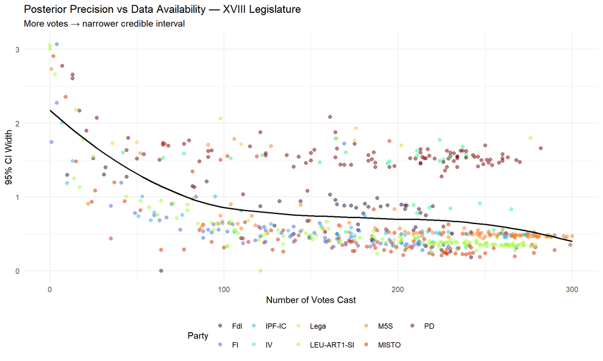

```r
ci_all_18 <- data.frame(
  legis.name = rownames(id_18$xbar),
  mean       = as.numeric(id_18$xbar[, 1]),
  lower      = apply(id_18$x[, , 1], 2, quantile, 0.025),
  upper      = apply(id_18$x[, , 1], 2, quantile, 0.975),
  stringsAsFactors = FALSE
)
ci_all_18$ci_width <- ci_all_18$upper - ci_all_18$lower
ci_all_18 <- merge(ci_all_18, votes_df_18, by = "legis.name", all.x = TRUE)
ci_all_18 <- merge(ci_all_18, data18[, c("legis.name", "partito")],
                   by = "legis.name", all.x = TRUE)

ggplot(ci_all_18, aes(x = n_votes, y = ci_width, color = partito)) +
  geom_point(alpha = 0.5, size = 1.8) +
  geom_smooth(method = "loess", se = FALSE, color = "black",
              linewidth = 0.8, aes(group = 1)) +
  scale_color_manual(values = party_colors_18) +
  theme_minimal() +
  labs(title    = "Posterior Precision vs Data Availability — XVIII Legislature",
       subtitle = "More votes → narrower credible interval",
       x = "Number of Votes Cast", y = "95% CI Width", color = "Party") +
  theme(legend.position = "bottom")
```

## Cross-Legislature Analysis: Party Switchers

Legislators present in both the XVIII and XIX legislatures who changed party affiliation offer a unique opportunity to assess whether the model captures individual ideology or merely party-line voting. If ideal points are stable across legislatures despite party changes, it suggests the estimates reflect genuine individual preferences. If they shift substantially, it may indicate that voting behaviour — and therefore estimated ideal points — is driven more by coalition dynamics than individual ideology.

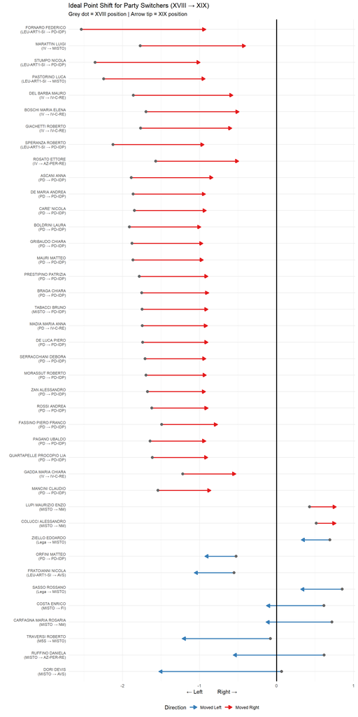

```r
ip_18 <- data.frame(
  legis.name = rownames(id_18$xbar),
  ip_18      = as.numeric(id_18$xbar[, 1]),
  stringsAsFactors = FALSE
)

ip_19 <- data.frame(
  legis.name = rownames(id_19$xbar),
  ip_19      = as.numeric(id_19$xbar[, 1]),
  stringsAsFactors = FALSE
)

party_18 <- data18[, c("legis.name", "partito")] %>%
  rename(partito_18 = partito) %>% distinct()
party_19 <- data19[, c("legis.name", "partito")] %>%
  rename(partito_19 = partito) %>% distinct()

switchers <- party_18 %>%
  inner_join(party_19, by = "legis.name") %>%
  filter(partito_18 != partito_19) %>%
  inner_join(ip_18, by = "legis.name") %>%
  inner_join(ip_19, by = "legis.name") %>%
  mutate(delta     = ip_19 - ip_18,
         direction = ifelse(delta > 0, "Moved Right", "Moved Left"),
         abs_delta = abs(delta)) %>%
  arrange(desc(abs_delta))

switchers$label <- paste0(switchers$legis.name, "\n(",
                           switchers$partito_18, " → ",
                           switchers$partito_19, ")")
ci_18 <- data.frame(
  legis.name = rownames(id_18$xbar),
  lower_18   = apply(id_18$x[, , 1], 2, quantile, 0.025),
  upper_18   = apply(id_18$x[, , 1], 2, quantile, 0.975),
  stringsAsFactors = FALSE
)

switchers <- switchers %>%
  inner_join(ci_18, by = "legis.name") %>%
  # Primary: XIX position must fall outside XVIII 95% CI
  filter(ip_19 < lower_18 | ip_19 > upper_18)

ggplot(switchers) +
  geom_segment(aes(x = ip_18, xend = ip_19,
                   y = reorder(label, delta), yend = reorder(label, delta),
                   color = direction),
               arrow = arrow(length = unit(0.25, "cm"), type = "closed"),
               linewidth = 0.9) +
  geom_point(aes(x = ip_18, y = reorder(label, delta)),
             shape = 16, size = 2.5, color = "gray40") +
  geom_vline(xintercept = 0, linewidth = 1, color = "black") +
  scale_color_manual(values = c("Moved Right" = "#E41A1C",
                                "Moved Left"  = "#377EB8")) +
  theme_minimal() +
  labs(title    = "Ideal Point Shift for Party Switchers (XVIII → XIX)",
       subtitle = "Grey dot = XVIII position | Arrow tip = XIX position",
       x = "← Left          Right →", y = "", color = "Direction") +
  theme(legend.position    = "bottom",
        axis.text.y        = element_text(size = 8),
        panel.grid.major.y = element_line(color = "gray90"))
```

## Conclusions

Due to strong party whipping, the estimation of ideal points for Italian legislators is considerably more challenging than in the US context, where members of Congress have historically enjoyed greater freedom in their voting behaviour — though increasing polarisation has reduced this in recent years. Nevertheless, the model remains a valid tool for extracting aggregate party positions and inter-party distances, even when individual-level estimates are imprecise.

[^1]: Clinton, J., Jackman, S., & Rivers, D. (2004). The Statistical Analysis of Roll Call Data. *American Political Science Review*, 98(2), 355–370. https://doi.org/10.1017/S0003055404001194
[^2]: https://rdocumentation.org/packages/pscl/versions/1.5.9
[^3]: Jackman, S. (2001). Multidimensional Analysis of Roll Call Data via Bayesian Simulation. *Political Analysis*, 9(3), 227–241. https://doi.org/10.1093/polana/9.3.227